# Activity Monitor

Bernard Fraenkel

September 19, 2015

# Introduction

It is now possible to collect a large amount of data about personal movement using activity monitoring devices such as a [Fitbit](http://www.fitbit.com/), [Nike Fuelband](http://www.nike.com/us/en_us/c/nikeplus-fuelband), or [Jawbone Up](https://jawbone.com/up). These type of devices are part of the “quantified self” movement – a group of enthusiasts who take measurements about themselves regularly to improve their health, to find patterns in their behavior, or because they are tech geeks. But these data remain under-utilized both because the raw data are hard to obtain and there is a lack of statistical methods and software for processing and interpreting the data.

This assignment makes use of data from a personal activity monitoring device. This device collects data at 5 minute intervals through out the day. The data consists of two months of data from an anonymous individual collected during the months of October and November, 2012 and include the number of steps taken in 5 minute intervals each day.

## Loading libraries and raw data

The data set is: [Activity monitoring data](https://d396qusza40orc.cloudfront.net/repdata%2Fdata%2Factivity.zip) [52K]

```r
# Code for Project 1 of Coursera Reproducible Research Course
# 9/16/2015

library(ggplot2)
library(gridExtra)
library(plyr) # Has to be before dplyr
library(dplyr)

# 1. Load the data
activity <- read.csv("activity.csv")
message(paste0("#Records in activity: "), nrow(activity))
```

## Processing the raw data into a format suitable for analysis

The first remove records that have NA values

```r
# Filter out the NAs
activity_clean <- activity[complete.cases(activity),]
message(paste0("#Records in activity_clean: "), nrow(activity_clean))
```

## Mean and median of total number of steps taken per day

The code below computes the total number of steps each day, and then computes the average

```r
# Calculate the total number of steps taken per day
daily_steps <- ddply(activity_clean, .(date), summarize, sum_steps=sum(steps))
av_daily_steps <- mean(daily_steps$sum_steps)
message(paste0("Mean total number of steps taken per day: "), round(av_daily_steps,0))
```

```
## Mean total number of steps taken per day: 10766
```

```r
med_daily_steps <- median(daily_steps$sum_steps)
message(paste0("Median of total number of steps taken per day: "), round(med_daily_steps,0))
```

```
## Median of total number of steps taken per day: 10765
```

The plot below shows the total number of steps taken each day

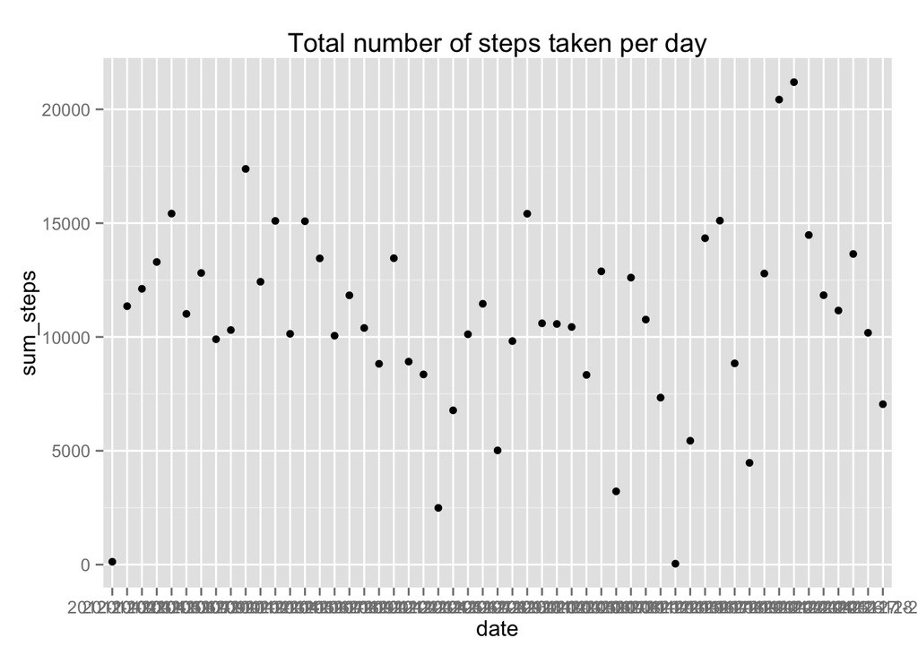

```r
g <- ggplot(daily_steps,aes(date, sum_steps))
g <- g + geom_point() + ggtitle("Total number of steps taken per day")
g
```

## Histogram of the total number of steps taken each day

The histogram shows a couple of noticeable peaks - probably corresponding to different types of workouts

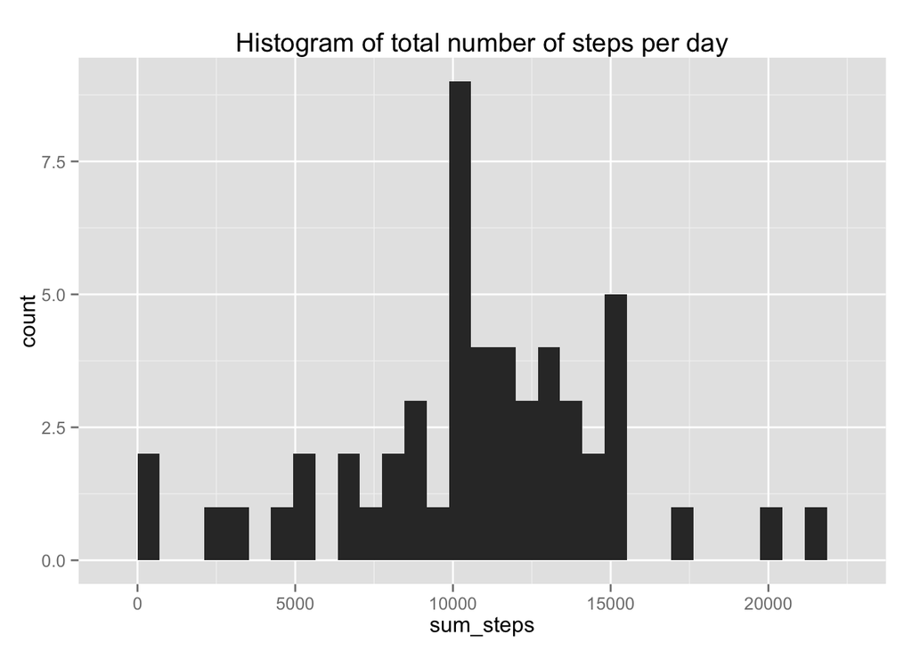

```r
qplot(sum_steps, data=daily_steps, geom="histogram", main="Histogram of total number of steps per day")
```

## Mean and median of the total number of steps taken per day

The mean and median of total number of steps taken per day are computed below

```r
mean_steps <- mean(daily_steps$sum_steps)
# mean_steps <- round(mean_steps,9)
median_steps <- median(daily_steps$sum_steps)
# median_steps <- round(median_steps,0)
message(paste0("daily average number of steps:", round(mean_steps,2)))
```

```
## daily average number of steps:10766.19
```

```r
message(paste0("median of steps taken per day:", round(median_steps,2)))
```

```
## median of steps taken per day:10765
```

## Average daily activity pattern

This is a time series plot of the 5-minute interval (x-axis) and the average number of steps taken, averaged across all days (y-axis) - thus showing the average daily patterns of activity

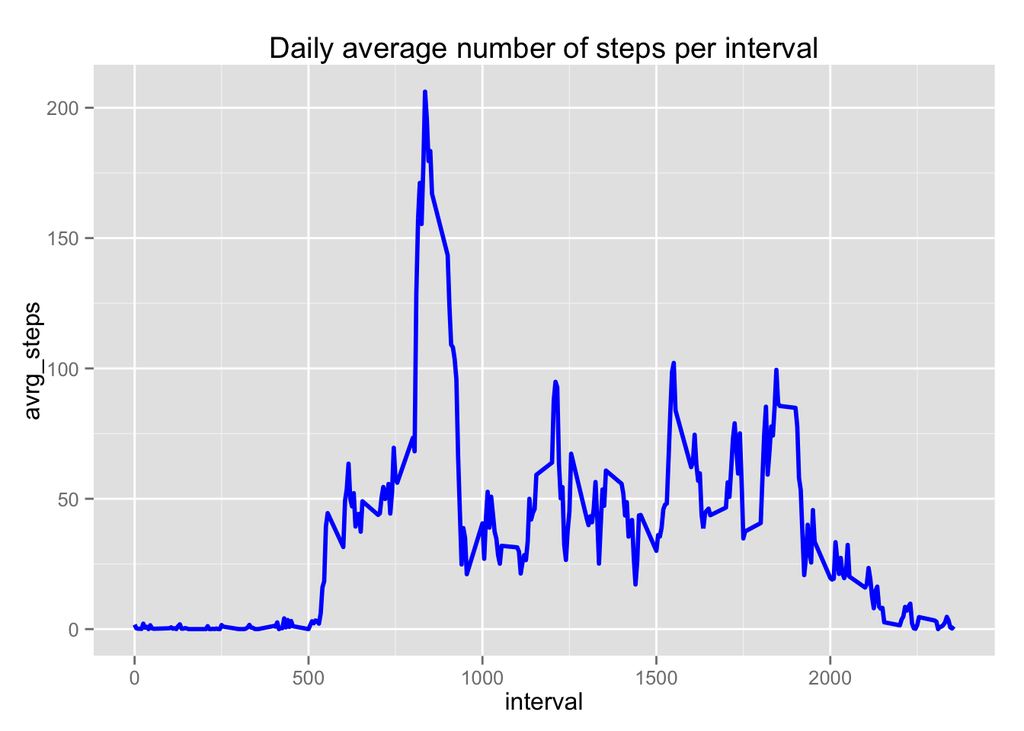

```r
interval_steps <- ddply(activity_clean, .(interval), summarize, sum_steps=sum(steps))
nb_days <- nrow(daily_steps)  # Number of days for which we have observations
# compute the average number of steps per interval
av_steps <- mutate(interval_steps, sum_steps = sum_steps/nb_days)
colnames(av_steps) <- c("interval", "avrg_steps")
g <- ggplot(av_steps, aes(interval, avrg_steps))
g <- g+geom_line(size=1,colour="blue")  + ggtitle("Daily average number of steps per interval")
g
```

## Interval with maximum number of steps

The 5-minute interval, on average across all the days in the dataset, which contains the maximum number of steps is

```r
av_steps_ordered <- av_steps[with(av_steps, order(-avrg_steps)),]
message(paste0("Interval with maximum number of steps: ", av_steps_ordered[1,"interval"]))
```

```
## Interval with maximum number of steps: 835
```

The time of ** maximum activity is thus around 8:30am **  
The plot also shows minor peaks at the typical times of activity: 12pm, 3:30pm and 7pm

# Imputing missing values

## Total number of missing values in the dataset

```r
activity_NA <- filter(activity, is.na(steps))
na_rows <- nrow(activity_NA)
message(paste0("#rows with missing data: "), na_rows, " - out of a total of: ", nrow(activity))
```

```
## #rows with missing data: 2304 - out of a total of: 17568
```

## Filling in all of the missing values in the dataset

The code below fills in missing data for a given interval with the overall average value for that interval

```r
# Replace NA values with the average values obtained from records with non-missing values: av_steps
# Create a new dataset that is equal to the original dataset but with the missing data filled in.
# Round the averages
# activity_full <- mutate(activity, steps = ifelse(is.na(steps), round(av_steps[av_steps$interval == interval, "avrg_steps"],0), steps))
activity_full <- mutate(activity, steps = ifelse(is.na(steps), round(av_steps[match(interval,av_steps$interval), "avrg_steps"],0), steps))
if(any(is.na(activity_full))) stop ("still some NAs")
```

## Histogram of the total number of steps taken each day

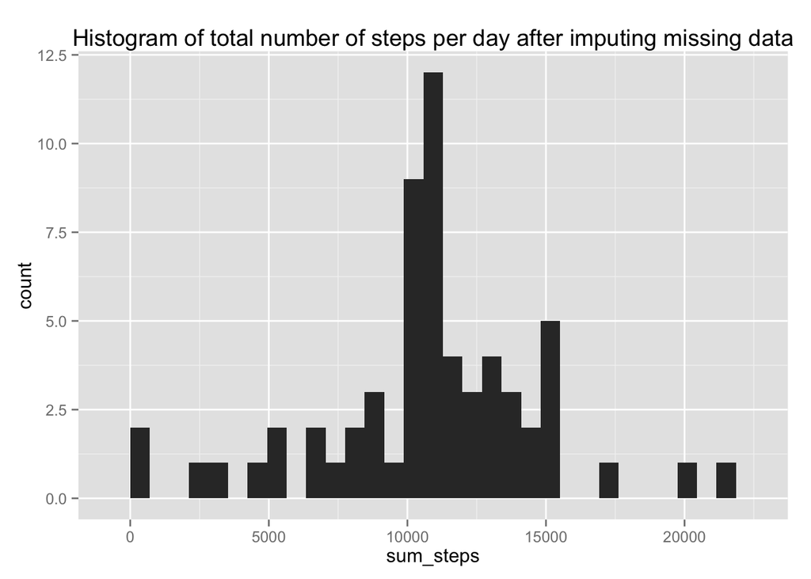

```r
daily_steps_full <- ddply(activity_full, .(date), summarize, sum_steps=sum(steps))
qplot(sum_steps, data=daily_steps_full, geom="histogram",  main="Histogram of total number of steps per day after imputing missing data")
```

```r
# Calculate and report the mean and median total number of steps taken per day.
mean_steps_full <- mean(daily_steps_full$sum_steps)
median_steps_full <- median(daily_steps_full$sum_steps)

message(paste0("daily average number of steps - after NA replacement:", round(mean_steps_full,2)))
```

```
## daily average number of steps - after NA replacement:10765.64
```

```r
message(paste0("median of steps taken per day  - after NA replacement:", round(median_steps_full,2)))
```

```
## median of steps taken per day  - after NA replacement:10762
```

These values are very similar to the ones computed without using the missing values because we used the average value per interval to fill in the missing values. Unless the missing values were concentrated on a limited number of time intervals, filling in missing values with the averages of the available data will have only minor impact on the overall average

Imputing missing data adds values around the average, but otherwise does not modify the distribution

## Differences in activity patterns between weekdays and weekends

Note that we use the dataset with the filled-in missing values for this part

```r
# Function to convert weekday names to weekday/weekend
day_vs_end <- function(date_str) {
    wkday <- weekdays(as.Date(date_str))
    ifelse(wkday == "Saturday" | wkday == "Sunday", "weekend", "weekday")
}
activity_final <- mutate(activity_full, day_vs_end = day_vs_end(date))
activity_final <- mutate(activity_final, day_vs_end = as.factor(day_vs_end))
# Split data set into 2
activity_weekday <- activity_final[activity_final$day_vs_end == "weekday", c("interval", "steps")]
activity_weekend <- activity_final[activity_final$day_vs_end == "weekend", c("interval", "steps")]
# interval_steps_final <- ddply(activity_final, .(interval), summarize, sum_steps=sum(steps))


# Make a panel plot containing a time series plot (i.e. type = "l") of the 5-minute interval (x-axis)
# and the average number of steps taken, averaged across all weekday days or weekend days (y-axis).
nb_wkdy <- nrow(activity_weekday)/288  # 288 5-min intervals per day
nb_wknd <- nrow(activity_weekend)/288
interval_steps_weekday <- ddply(activity_weekday, .(interval), summarize, av_steps=sum(steps)/nb_wkdy)
interval_steps_weekend <- ddply(activity_weekend, .(interval), summarize, av_steps=sum(steps)/nb_wknd)
message(paste0("Average number of steps per 5-min on weekdays: ", round(sum(interval_steps_weekday$av_steps),2)))
```

```
## Average number of steps per 5-min on weekdays: 10255.29
```

```r
message(paste0("Average number of steps  per 5-min on weekend days: ", round(sum(interval_steps_weekend$av_steps),2)))
```

```
## Average number of steps  per 5-min on weekend days: 12201
```

This shows that the subject is about ** 20% more active during weekends **

The 2 plots below compare activity during weekdays versus weekends

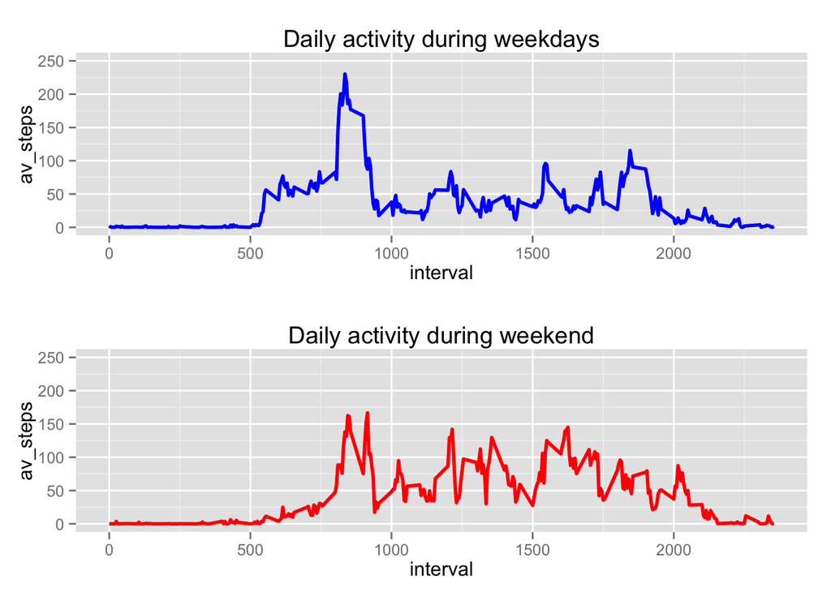

```r
g <- ggplot(interval_steps_weekday,aes(interval, av_steps))
g <- g+geom_line(size=1,colour="blue") + ggtitle("Daily activity during weekdays") + ylim(0,250)
q <- ggplot(interval_steps_weekend,aes(interval, av_steps))
q <- q+geom_line(size=1,colour="red") + ggtitle("Daily activity during weekend") + ylim(0,250)
grid.arrange(g, q, nrow=2)
```